# Risk Factor Analysis

[output not shown]

```
##       subjid          ses    sex        haz
##    1:      1       Middle   Male  2.6100000
##    2:      1       Middle   Male  1.3500000
##    3:      2            .   Male  0.5000000
##    4:      2            .   Male -1.1700000
##    5:      2            .   Male -1.4664795
##   ---
## 1424:    500 Lower-middle Female  1.4400000
## 1425:    500 Lower-middle Female  1.1500000
## 1426:    500 Lower-middle Female  0.9455342
## 1427:    501       Middle   Male -2.1400000
## 1428:    501       Middle   Male  0.5100000
```

```
## $A
## [1] "sex"
##
## $Y
## [1] "haz"
##
## $id
## [1] "subjid"
##
## $strata
## [1] "ses"
```

## Outcome Variable

**Outcome Variable:** haz

## Predictor Variables

**Intervention Variable:** sex

**Adjustment Set:**

unadjusted

## Stratifying Variables

The analysis was stratified on these variable(s):

- ses

## Data Summary

| ses | sex | n_cell | n | outcome_variable |
| --- | --- | --- | --- | --- |
| . | Female | 88 | 160 | haz |
| . | Male | 72 | 160 | haz |
| Low | Female | 5 | 5 | haz |
| Low | Male | 0 | 5 | haz |
| Lower-middle | Female | 113 | 232 | haz |
| Lower-middle | Male | 119 | 232 | haz |
| Middle | Female | 225 | 483 | haz |
| Middle | Male | 258 | 483 | haz |
| Upper | Female | 62 | 112 | haz |
| Upper | Male | 50 | 112 | haz |
| Upper-middle | Female | 218 | 436 | haz |
| Upper-middle | Male | 218 | 436 | haz |

The following strata were considered:

- ses: .
- ses: Low
- ses: Lower-middle
- ses: Middle
- ses: Upper
- ses: Upper-middle

### Dropped Strata

- ses: Low

## Methods Detail

We’re interested in the causal parameters $E[Y_a]$ for all values of $a \in \mathcal{A}$. These parameters represent the mean outcome if, possibly contrary to fact, we intervened to set all units to have $A=a$. Under the randomization and positivity assumptions, these are identified by the statistical parameters $\psi_a=E_W[E_{Y|A,W}(Y|A=a,W)]$. In addition, we’re interested in the mean of $Y$, $E[Y]$ under no intervention (the observed mean). We will estimate these parameters by using SuperLearner to fit the relevant likelihood factors – $E_{Y|A,W}(Y|A=a,W)$ and $p(A=a|W)$, and then updating our likelihood fit using a joint TMLE.

For unadjusted analyses ($W=\{\}$), initial likelihoods were estimated using Lrnr_glm to estimate the simple $E(Y|A)$ and Lrnr_mean to estimate $p(A)$. For adjusted analyses, a small library containing Lrnr_glmnet, Lrnr_xgboost, and Lrnr_mean was used.

# Results Detail

## Results Plots

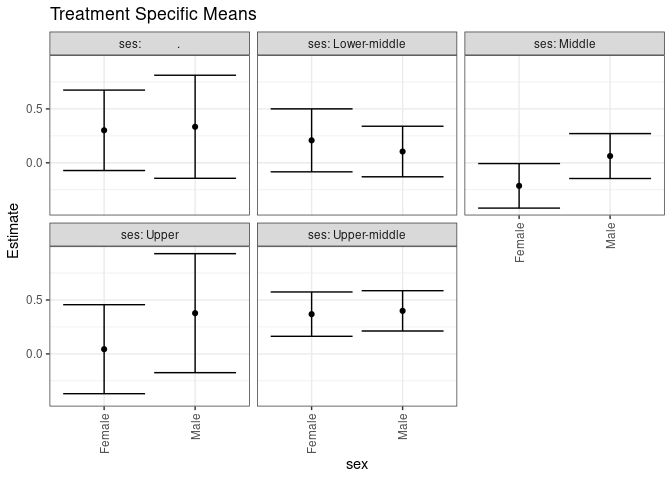

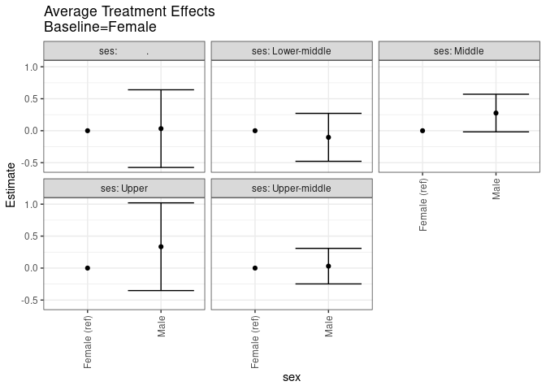

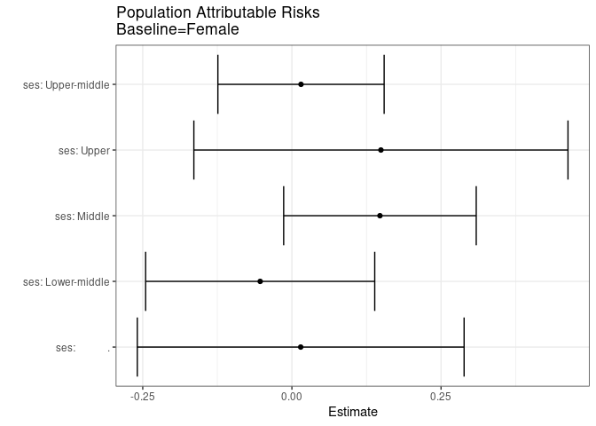

## Results Table

### Parameter: TSM

| ses | intervention_level | baseline_level | estimate | ci_lower | ci_upper |
| --- | --- | --- | --- | --- | --- |
| . | Female | NA | 0.3015280 | -0.0716396 | 0.6746956 |
| . | Male | NA | 0.3342940 | -0.1437351 | 0.8123231 |
| Lower-middle | Female | NA | 0.2084250 | -0.0836228 | 0.5004728 |
| Lower-middle | Male | NA | 0.1047689 | -0.1297872 | 0.3393250 |
| Middle | Female | NA | -0.2136989 | -0.4203251 | -0.0070727 |
| Middle | Male | NA | 0.0625613 | -0.1457715 | 0.2708941 |
| Upper | Female | NA | 0.0435457 | -0.3692850 | 0.4563764 |
| Upper | Male | NA | 0.3777419 | -0.1743487 | 0.9298325 |
| Upper-middle | Female | NA | 0.3686204 | 0.1629634 | 0.5742774 |
| Upper-middle | Male | NA | 0.3991411 | 0.2122311 | 0.5860512 |

### Parameter: E(Y)

| ses | intervention_level | baseline_level | estimate | ci_lower | ci_upper |
| --- | --- | --- | --- | --- | --- |
| . | NA | NA | 0.3162727 | 0.0196704 | 0.6128750 |
| Lower-middle | NA | NA | 0.1552566 | -0.0311575 | 0.3416707 |
| Middle | NA | NA | -0.0661313 | -0.2137862 | 0.0815235 |
| Upper | NA | NA | 0.1927404 | -0.1409880 | 0.5264689 |
| Upper-middle | NA | NA | 0.3838808 | 0.2451429 | 0.5226187 |

### Parameter: ATE

| ses | intervention_level | baseline_level | estimate | ci_lower | ci_upper |
| --- | --- | --- | --- | --- | --- |
| . | Female | Female | 0.0000000 | 0.0000000 | 0.0000000 |
| . | Male | Female | 0.0327660 | -0.5749248 | 0.6404568 |
| Lower-middle | Female | Female | 0.0000000 | 0.0000000 | 0.0000000 |
| Lower-middle | Male | Female | -0.1036561 | -0.4784984 | 0.2711862 |
| Middle | Female | Female | 0.0000000 | 0.0000000 | 0.0000000 |
| Middle | Male | Female | 0.2762603 | -0.0182651 | 0.5707856 |
| Upper | Female | Female | 0.0000000 | 0.0000000 | 0.0000000 |
| Upper | Male | Female | 0.3341962 | -0.3520029 | 1.0203953 |
| Upper-middle | Female | Female | 0.0000000 | 0.0000000 | 0.0000000 |
| Upper-middle | Male | Female | 0.0305207 | -0.2477304 | 0.3087718 |

### Parameter: PAR

| ses | intervention_level | baseline_level | estimate | ci_lower | ci_upper |
| --- | --- | --- | --- | --- | --- |
| . | Female | NA | 0.0147447 | -0.2591315 | 0.2886209 |
| Lower-middle | Female | NA | -0.0531684 | -0.2451615 | 0.1388246 |
| Middle | Female | NA | 0.1475676 | -0.0137971 | 0.3089323 |
| Upper | Female | NA | 0.1491947 | -0.1643411 | 0.4627306 |
| Upper-middle | Female | NA | 0.0152604 | -0.1240680 | 0.1545888 |